# MATH 4753 Project 2

### 4.11.1 Residuals vs Fitted

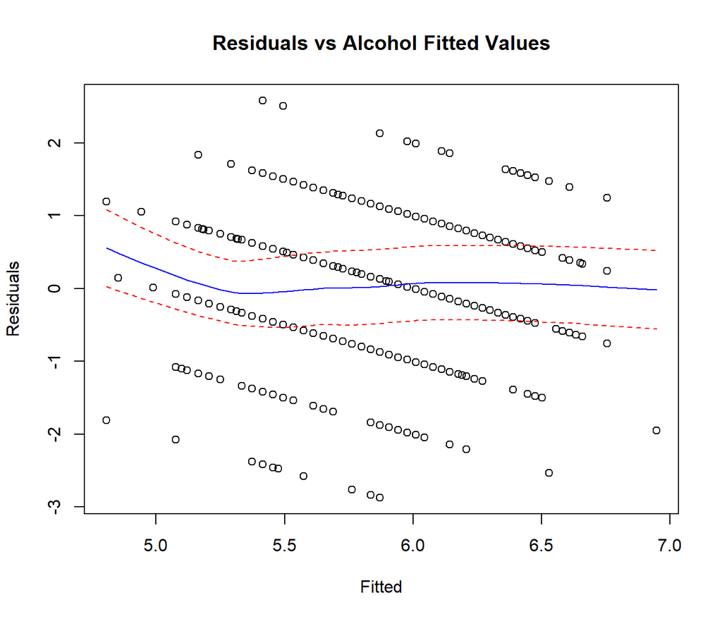

```r
qwine.resa=residuals(quada.lm)
fwine.fita=fitted(quada.lm)
trendscatter(qwine.resa~fwine.fita,f=0.5,data=wine.alc,xlab="Fitted",ylab="Residuals",main="Residuals vs Alcohol Fitted Values")
```

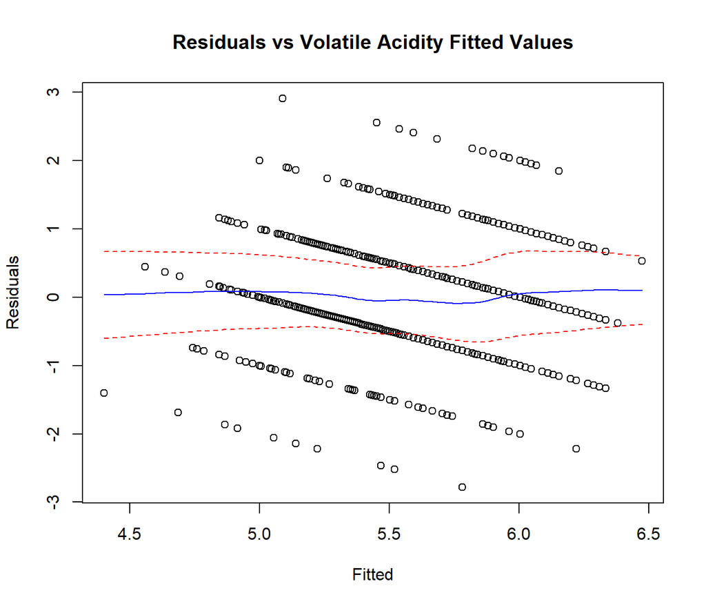

```r
qwine.resv=residuals(quadv.lm)
fwine.fitv=fitted(quadv.lm)
trendscatter(qwine.resv~fwine.fitv,f=0.5,data=wine.alc,xlab="Fitted",ylab="Residuals",main="Residuals vs Volatile Acidity Fitted Values")
```

Each trend line is not straight about 0 on the y-axis, so the plots are “unsatisfactory”.

### 4.11.2 Normality

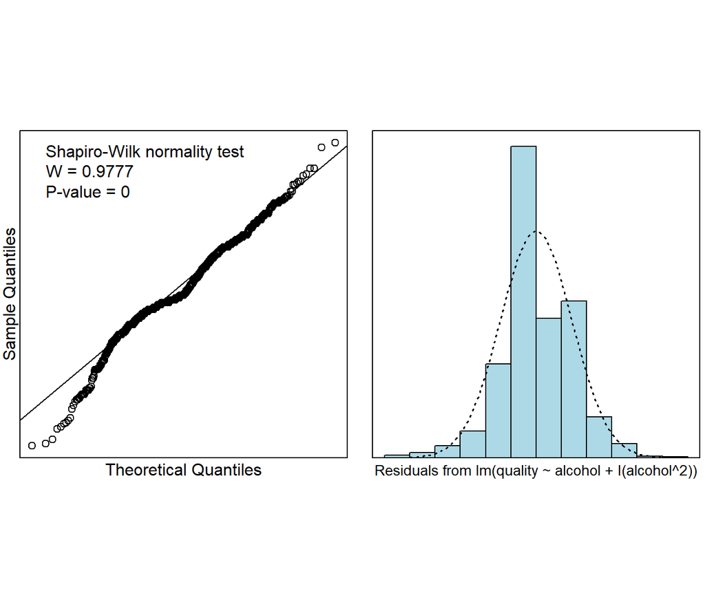

```r
normcheck(quada.lm,shapiro.wilk=TRUE)
```

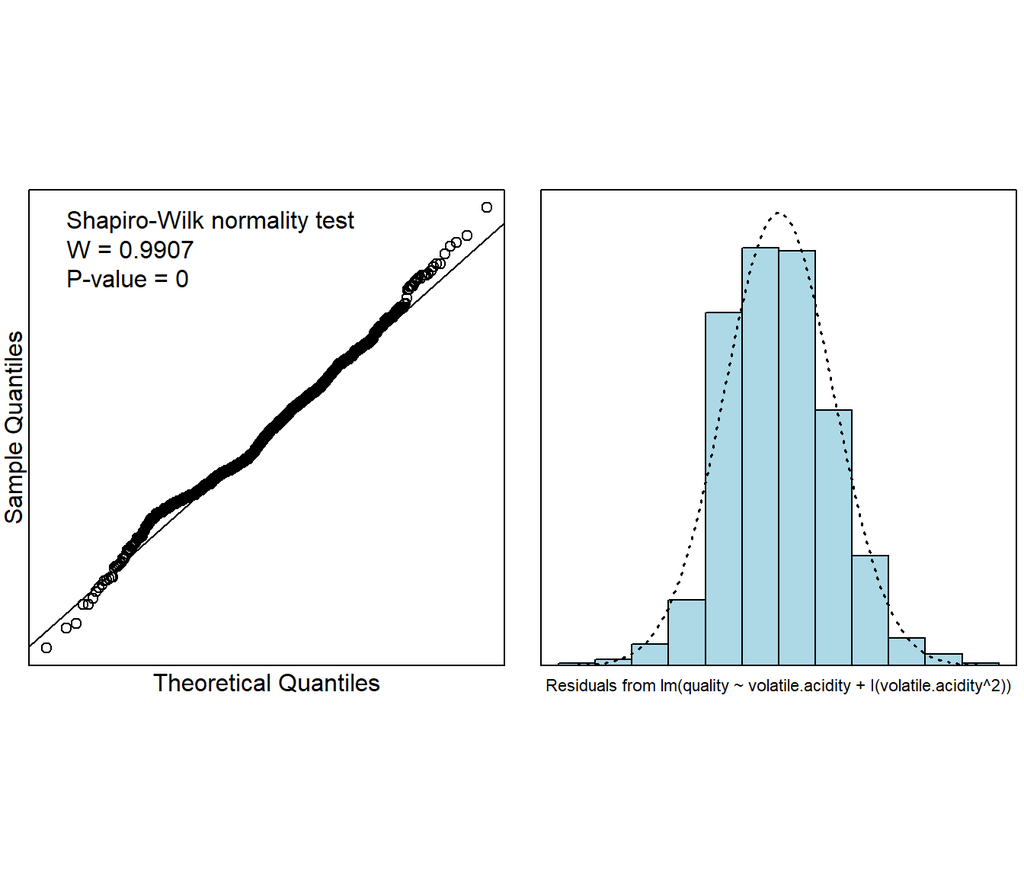

```r
normcheck(quadv.lm,shapiro.wilk=TRUE)
```

We obtain a p-value of 0 for both, so we reject the Null hypothesis that the errors are distributed normally. The results of the Shapiro-Wilk test tell us that we have enough evidence to reject the null hypothesis (p-value of 0). This tells us that the data is not distributed normally.

### 4.11.3 Comparing Models

While neither model is very good for the data, we have evidence that the quadratic model is a better fit than the linear. For the linear model, we obtained 0.2267 and 0.1525 for the multiple $R^2$ values for alcohol and volatile acidity, respectively. In the quadratic model, we obtained 0.228 and 0.1544 for the multiple $R^2$ values for alcohol and volatile acidity, respectively. Although only slightly higher, this still indicates that a quadratic model will fit better than a linear model.